# EXAM_2_NOTES

## Other Aesthetics

There are lots of options for aesthetics. An aesthetic can be assigned to either numeric or categorical data. `fill` is a common grouping option; notice that an appropriate key is displayed when you use one of these options.

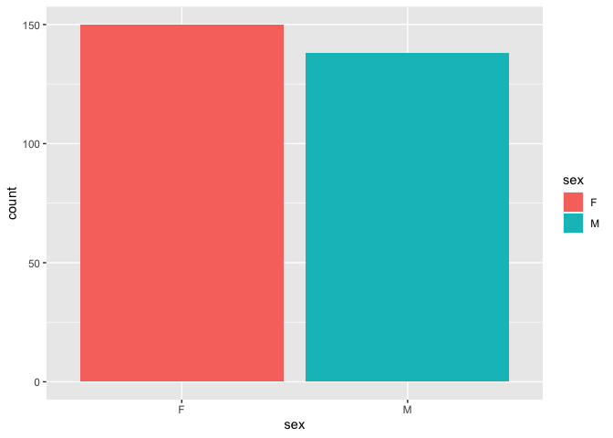

```r
elephants %>%
  ggplot(aes(x=sex, fill=sex))+ #fill is a grouping option
  geom_bar()
```

`size` adjusts the size of points relative to a continuous variable.

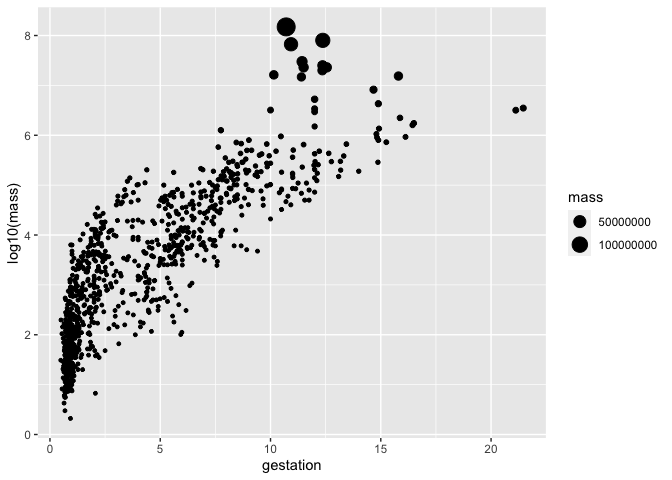

```r
life_history %>%
  ggplot(aes(x=gestation, y=log10(mass), size=mass))+
  geom_point(na.rm=T)
```

## Load the libraries

```r
library(tidyverse)
library(janitor)
library(palmerpenguins)
```

## Removes scientific notation

```r
options(scipen=999) #cancels the use of scientific notation for the session
```

## Data

**Database of vertebrate home range sizes.**  
Reference: Tamburello N, Cote IM, Dulvy NK (2015) Energy and the scaling of animal space use. The American Naturalist 186(2):196-211. http://dx.doi.org/10.1086/682070.  
Data: http://datadryad.org/resource/doi:10.5061/dryad.q5j65/1

```r
homerange <-
  read_csv("data/Tamburelloetal_HomeRangeDatabase.csv", na = c("", "NA", "\\"))
```

## A few more useful aesthetics

There are many options to create nice plots in ggplot. One useful trick is to store the plot as a new object and then experiment with geom’s and aesthetics. Let’s setup a plot that compares `log10.mass` and `log10.hra.` Notice that we are not specifying a geom.

```r
p <- homerange %>%
  ggplot(aes(x= log10.mass, y= log10.hra))
```

Play with point size by adjusting the `size` argument.

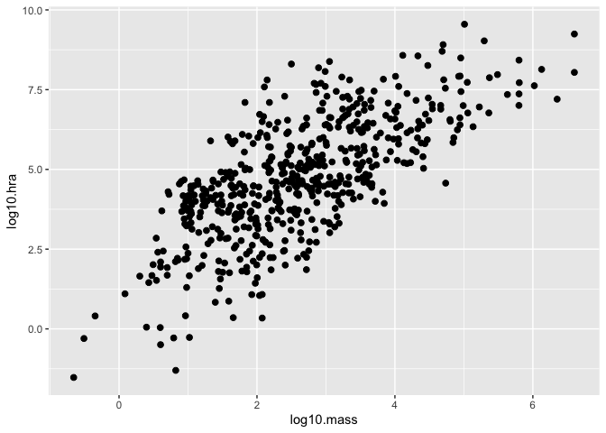

```r
p + geom_point(size=2)
```

We can color the points by a categorical variable.

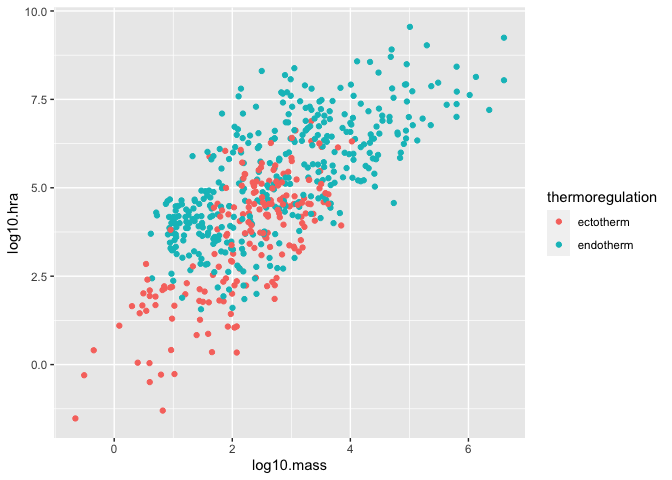

```r
p + geom_point(aes(color=thermoregulation), size=1.5) #for scatterplots, color is the same as fill in barplots
```

We can also map shapes to another categorical variable.

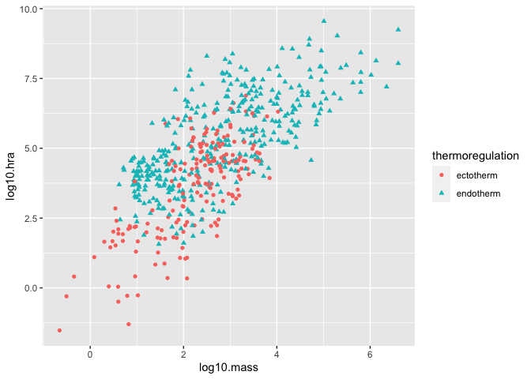

```r
p + geom_point(aes(color=thermoregulation, shape=thermoregulation), size=1.5)
```

## Barplots and multiple variables

At this point you should be comfortable building bar plots that show counts of observations using `geom_bar()`. Last time we explored the `fill` option as a way to bring color to the plot; i.e. we filled by the same variable that we were plotting. What happens when we fill by a different categorical variable?  
Let’s start by counting how many observations we have in each taxonomic group.

```r
homerange %>% count(taxon, sort=T)
```

```
## # A tibble: 9 × 2
##   taxon             n
##   <chr>         <int>
## 1 mammals         238
## 2 birds           140
## 3 marine fishes    90
## 4 snakes           41
## 5 river fishes     14
## 6 turtles          14
## 7 tortoises        12
## 8 lizards          11
## 9 lake fishes       9
```

Now let’s make a bar plot of these data.

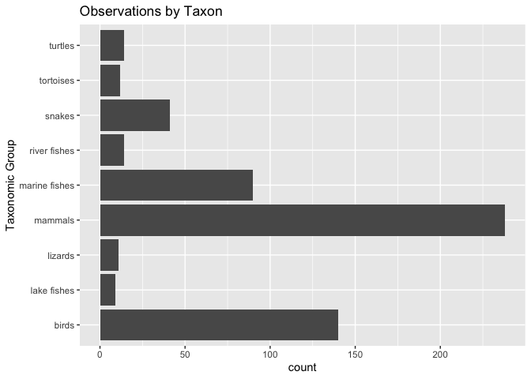

```r
homerange %>%
  ggplot(aes(taxon))+
  geom_bar()+
  coord_flip()+
  labs(title="Observations by Taxon",
       x="Taxonomic Group")
```

By specifying `fill=trophic.guild` we build a stacked bar plot that shows the proportion of a given taxonomic group that is an herbivore or carnivore.

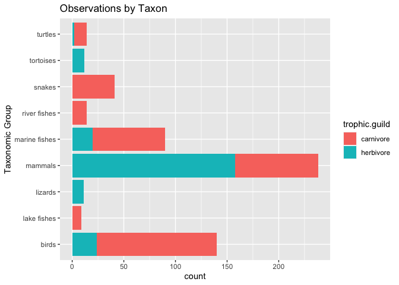

```r
homerange %>%
  ggplot(aes(x=taxon, fill=trophic.guild))+
  geom_bar()+
  coord_flip()+
  labs(title="Observations by Taxon",
       x="Taxonomic Group")
```

We can also have counts of each trophic guild within taxonomic group shown side-by-side by specifying `position="dodge"`.

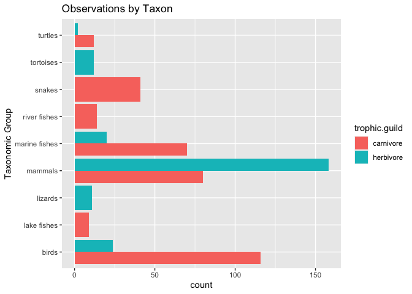

```r
homerange %>%
  ggplot(aes(x=taxon, fill=trophic.guild))+
  geom_bar(position="dodge")+
  coord_flip()+
  labs(title="Observations by Taxon",
       x="Taxonomic Group")
```

Here is the same plot oriented vertically.

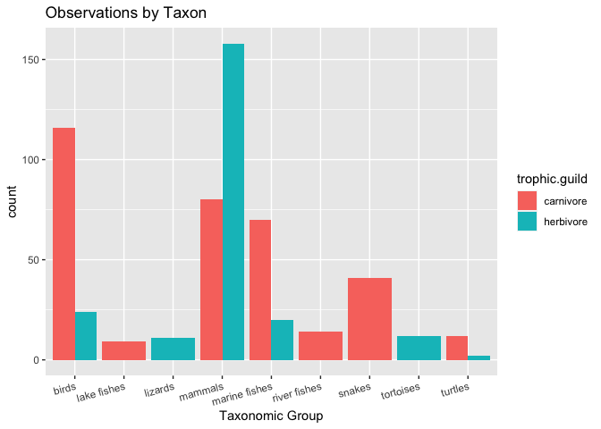

```r
homerange %>%
  ggplot(aes(x=taxon, fill=trophic.guild))+
  geom_bar(position="dodge")+
  theme(axis.text.x=element_text(angle=15, hjust = 1))+
  labs(title="Observations by Taxon",
       x="Taxonomic Group")
```

We can also scale all bars to a percentage.

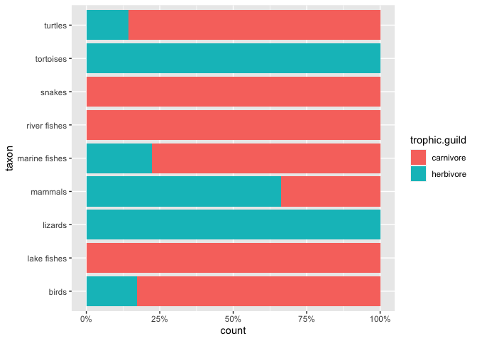

```r
homerange %>%
  ggplot(aes(x = taxon, fill = trophic.guild))+
  geom_bar(position = position_fill())+
  scale_y_continuous(labels = scales::percent)+
  coord_flip()
```

## Practice

For this practice, let’s use the [palmerpenguins](https://allisonhorst.github.io/palmerpenguins/articles/intro.html) data.

1. Make a bar plot that shows counts of individuals by island. Fill by species, and try both a stacked bar plot and `position="dodge"`.

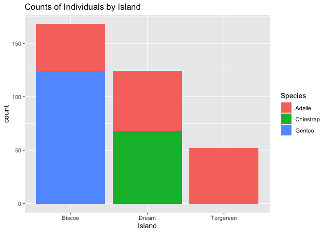

```r
penguins %>%
  ggplot(aes(x=island, fill=species))+
  geom_bar()+
  labs(title="Counts of Individuals by Island",
       x="Island",
       fill="Species")
```

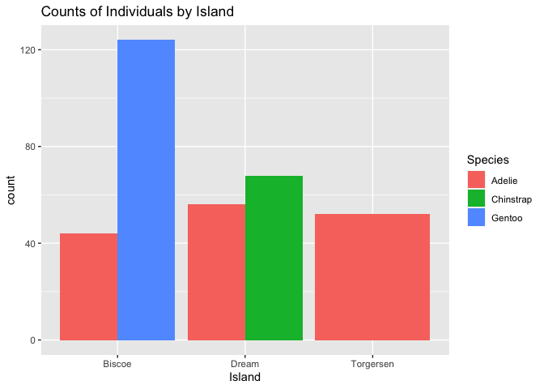

```r
penguins %>%
  ggplot(aes(x=island, fill=species))+
  geom_bar(position="dodge")+
  labs(title="Counts of Individuals by Island",
       x="Island",
       fill="Species")
```

2. Make another bar plot that shows the number of individuals by sex on each island?

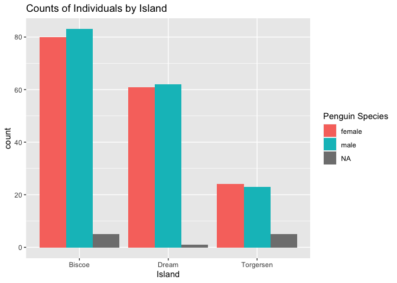

```r
penguins %>%
  #filter(sex!="NA") %>% # this removes the NA's
  ggplot(aes(x=island, fill=sex))+
  geom_bar(position="dodge")+
  labs(title="Counts of Individuals by Island",
       x="Island",
       fill="Penguin Species")
```

## Using `group`

In addition to `fill`, `group` is an aesthetic that accomplishes the same function but does not add color.

Here is a box plot that shows `log10.mass` by taxonomic `class.`

```r
homerange %>%
  ggplot(aes(x = class, y = log10.mass)) +
  geom_boxplot()
```

[output not shown]

I use `group` to make individual box plots for each taxon within class.

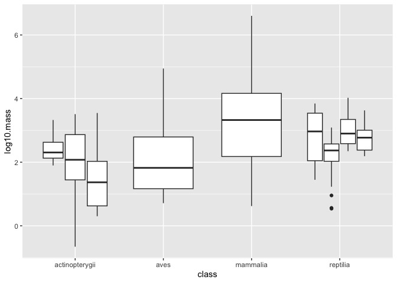

```r
homerange %>%
  ggplot(aes(x = class, y = log10.mass, group = taxon)) +
  geom_boxplot()
```

I can also use `fill` to associate the different taxa with a color coded key.

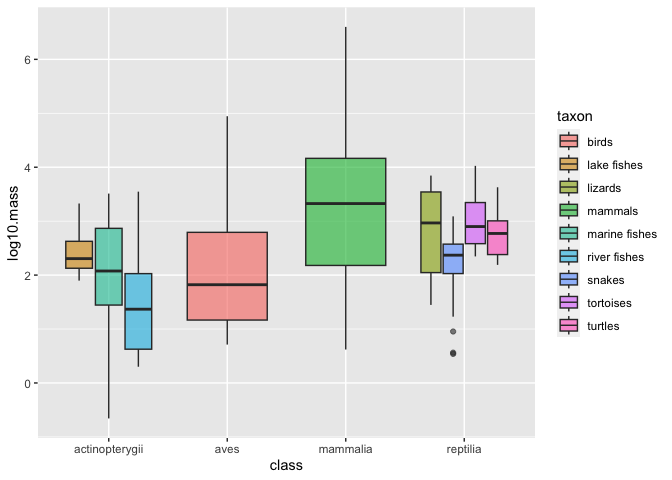

```r
homerange %>%
  ggplot(aes(x = class, y = log10.mass, fill=taxon)) +
  geom_boxplot(alpha=0.6)
```

```r
#install.packages("RColorBrewer")
#install.packages("paletteer")
#install.packages("ggthemes")
```

## Load the libraries

```r
library(tidyverse)
library(RColorBrewer)
library(paletteer)
library(janitor)
```

```r
options(scipen=999) #cancels the use of scientific notation for the session
```

## Data

For this tutorial, we will use two data sets.

[Desert ecology](http://esapubs.org/archive/ecol/E090/118/). The data are from: S. K. Morgan Ernest, Thomas J. Valone, and James H. Brown. 2009. Long-term monitoring and experimental manipulation of a Chihuahuan Desert ecosystem near Portal, Arizona, USA. Ecology 90:1708.

```r
deserts <- read_csv("data/surveys_complete.csv")
```

[Homerange](http://datadryad.org/resource/doi:10.5061/dryad.q5j65/1). The data are from: Tamburello N, Cote IM, Dulvy NK (2015) Energy and the scaling of animal space use. The American Naturalist 186(2):196-211. http://dx.doi.org/10.1086/682070.

```r
homerange <- read_csv("data/Tamburelloetal_HomeRangeDatabase.csv", na = c("", "NA", "\\"))
```

## Review

1. Use the `homerange` data to make a boxplot that shows the range of `log10.mass` by taxonomic class.

```r
homerange %>%
  ggplot(aes(x=class, y=log10.mass))+
  geom_boxplot()
```

[output not shown]

2. Now, add a layer to this plot that fills color for each box by taxonomic class

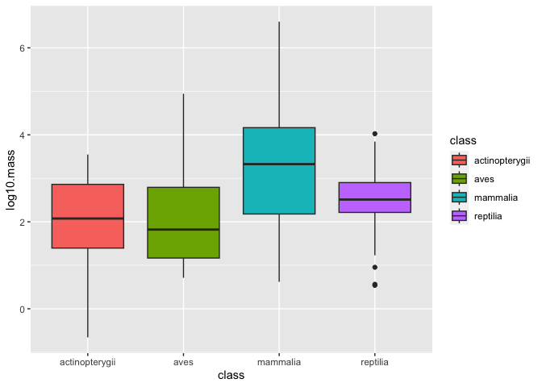

```r
homerange %>%
  ggplot(aes(x=class, y=log10.mass, fill=class))+
  geom_boxplot()
```

3. Use `group` to show the range of `log10.mass` by taxon.

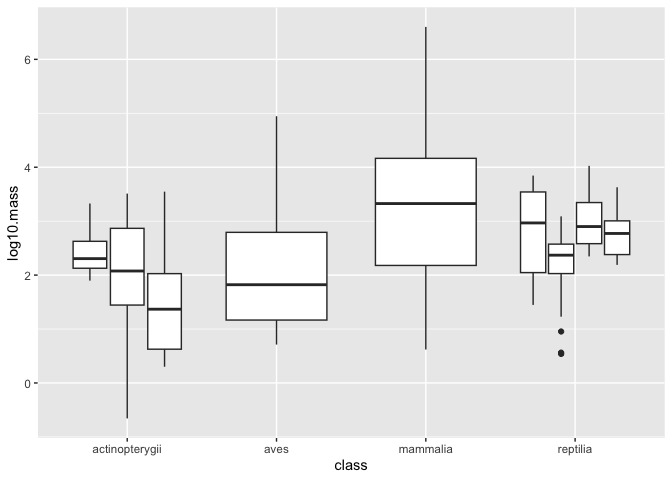

```r
homerange %>%
  ggplot(aes(x=class, y=log10.mass, group=taxon))+
  geom_boxplot()
```

4. Use `fill` to show the range of `log10.mass` by taxon with color codes.

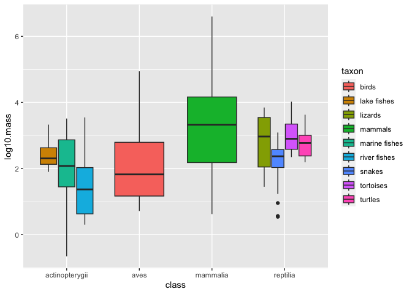

```r
homerange %>%
  ggplot(aes(x=class, y=log10.mass, fill=taxon))+
  geom_boxplot()
```

## Line plots

Line plots are great when you need to show changes over time. Here we look at the number of samples for species DM and DS over the years represented in the `deserts` data. This takes some careful thought- we want to know how sampling has changed over time for these two species.

Let’s start by making a clear x and y so we know what we are going to plot.

```r
deserts %>%
  filter(species_id=="DM" | species_id=="DS") %>%
  mutate(year=as.factor(year)) %>%
  group_by(year, species_id) %>%
  summarize(n=n(), .groups = 'keep') %>%
  pivot_wider(names_from = species_id, values_from = n)
```

```
## # A tibble: 26 × 3
## # Groups:   year [26]
##    year     DM    DS
##    <fct> <int> <int>
##  1 1977    264    98
##  2 1978    389   320
##  3 1979    209   204
##  4 1980    493   346
##  5 1981    559   354
##  6 1982    609   354
##  7 1983    528   280
##  8 1984    396    76
##  9 1985    667    98
## 10 1986    406    88
## # ℹ 16 more rows
```

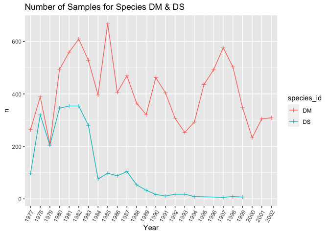

```r
deserts %>%
  filter(species_id=="DM" | species_id=="DS") %>%
  mutate(year=as.factor(year)) %>%
  group_by(year, species_id) %>%
  summarize(n=n(), .groups = 'keep') %>%
  ggplot(aes(x=year, y=n, group=species_id, color=species_id))+
  geom_line()+
  geom_point(shape=3)+ #you can experiment with shapes
  theme(axis.text.x=element_text(angle=60, hjust=1))+
  labs(title="Number of Samples for Species DM & DS",
       x="Year",
       y="n")
```

## Histograms

Histograms are frequently used by biologists; they show the distribution of continuous variables. As students, you have seen histograms of grade distributions. A histogram `bins` the data and you specify the number of bins that encompass a range of observations. For something like grades, this is easy because the number of bins corresponds to the grades A-F. By default, R uses a formula to calculate the number of bins but some adjustment may be required.

What does the distribution of body mass look like in the `homerange` data?

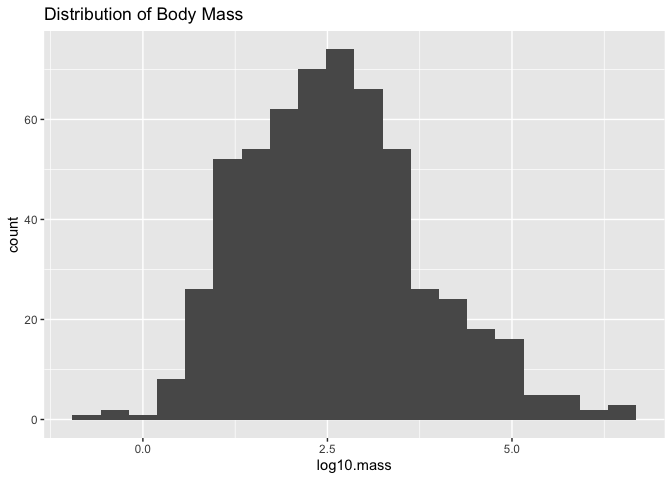

```r
homerange %>%
  ggplot(aes(x = log10.mass)) +
  geom_histogram(bins = 20)+ #we can adjust the number of bins with the bins argument
  labs(title = "Distribution of Body Mass")
```

Let’s play with the colors. This shows all 657 of R’s built-in colors. Notice that `color` and `fill` do different things!

```r
grDevices::colors()
```

```
##   [1] "white"                "aliceblue"            "antiquewhite"
##   [4] "antiquewhite1"        "antiquewhite2"        "antiquewhite3"
##   [7] "antiquewhite4"        "aquamarine"           "aquamarine1"
##  [10] "aquamarine2"          "aquamarine3"          "aquamarine4"
##  [13] "azure"                "azure1"               "azure2"
##  [16] "azure3"               "azure4"               "beige"
##  [19] "bisque"               "bisque1"              "bisque2"
##  [22] "bisque3"              "bisque4"              "black"
##  [25] "blanchedalmond"       "blue"                 "blue1"
##  [28] "blue2"                "blue3"                "blue4"
##  [31] "blueviolet"           "brown"                "brown1"
##  [34] "brown2"               "brown3"               "brown4"
##  [37] "burlywood"            "burlywood1"           "burlywood2"
##  [40] "burlywood3"           "burlywood4"           "cadetblue"
##  [43] "cadetblue1"           "cadetblue2"           "cadetblue3"
```

[output cut: 204 more lines]

Let’s rebuild the histogram, but this time we will specify the color and fill. Do a little experimentation on your own with the different colors.

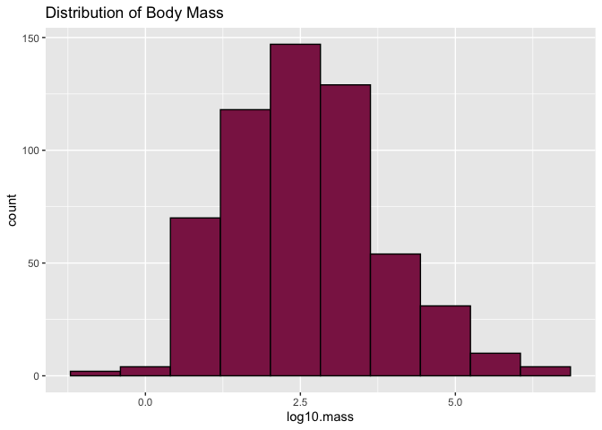

```r
homerange %>%
  ggplot(aes(x = log10.mass)) +
  geom_histogram(color = "black", fill = "violetred4", bins=10)+
  labs(title = "Distribution of Body Mass")
```

## Density plots

Density plots are similar to histograms but they use a smoothing function to make the distribution more even and clean looking. They do not use bins.

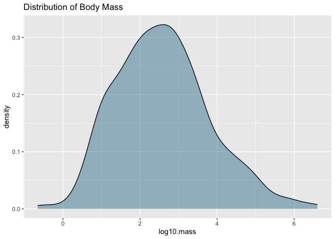

```r
homerange %>%
  ggplot(aes(x = log10.mass)) +
  geom_density(fill="deepskyblue4", alpha  =0.4, color = "black")+ #alpha is the transparency
  labs(title = "Distribution of Body Mass")
```

I like to see both the histogram and the density curve so I often plot them together. Note that I assign the density plot a different color.

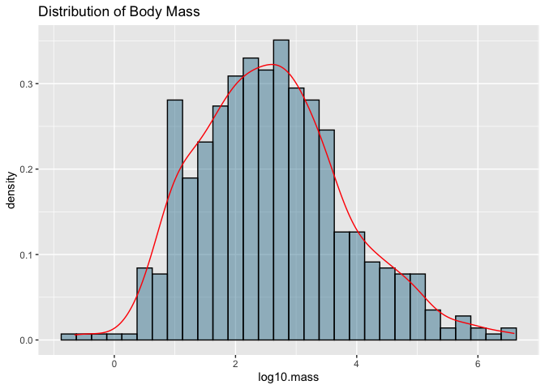

```r
homerange %>%
  ggplot(aes(x=log10.mass)) +
  geom_histogram(aes(y = after_stat(density)), fill = "deepskyblue4", alpha = 0.4, color = "black")+
  geom_density(color = "red")+
  labs(title = "Distribution of Body Mass")
```

## Practice

1. Make a histogram of `log10.hra`. Make sure to add a title.

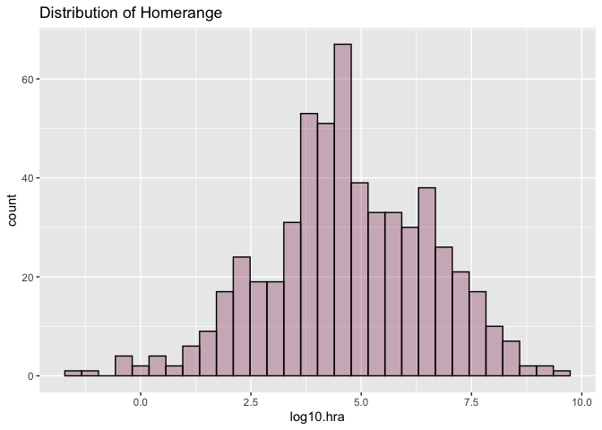

```r
homerange %>%
  ggplot(aes(x=log10.hra))+ #only need to specify an x
  geom_histogram(color="black", fill="violetred4", alpha=0.3)+
  labs(title="Distribution of Homerange")
```

2. Now plot the same variable using `geom_density()`.

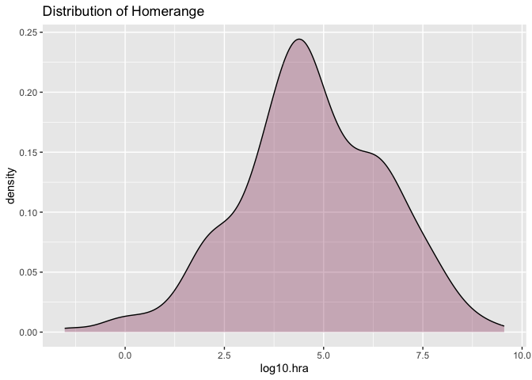

```r
homerange %>%
  ggplot(aes(x=log10.hra))+ #only need to specify an x
  geom_density(color="black", fill="violetred4", alpha=0.3)+
  labs(title="Distribution of Homerange")
```

3. Combine them both!

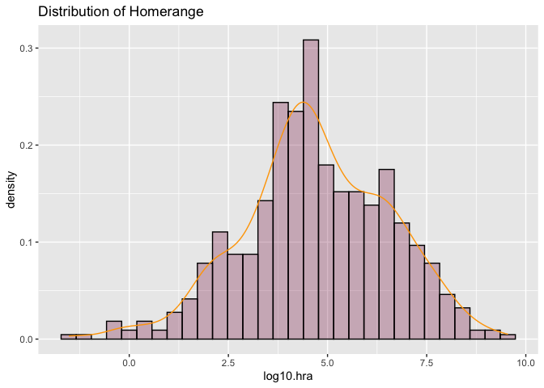

```r
homerange %>%
  ggplot(aes(x=log10.hra))+
  geom_histogram(aes(y=after_stat(density)), fill="violetred4", alpha=0.3, color="black")+
  geom_density(color="orange")+
  labs(title="Distribution of Homerange")
```

## Create Categories with mutate and case_when()

`case_when()` is a very handy function from `dplyr` which allows us to calculate a new variable from other variables. We use `case_when()` within `mutate()` to do this.`case_when()` allows us to specify multiple conditions. Let’s reclassify the body mass variable into a new factor variable with small, medium, and large animals. In this case, we are making a continuous variable into a categorical variable.

```r
glimpse(homerange)
```

```
## Rows: 569
## Columns: 24
## $ taxon                      <chr> "lake fishes", "river fishes", "river fishe…
## $ common.name                <chr> "american eel", "blacktail redhorse", "cent…
## $ class                      <chr> "actinopterygii", "actinopterygii", "actino…
## $ order                      <chr> "anguilliformes", "cypriniformes", "cyprini…
## $ family                     <chr> "anguillidae", "catostomidae", "cyprinidae"…
## $ genus                      <chr> "anguilla", "moxostoma", "campostoma", "cli…
## $ species                    <chr> "rostrata", "poecilura", "anomalum", "fundu…
## $ primarymethod              <chr> "telemetry", "mark-recapture", "mark-recapt…
## $ N                          <chr> "16", NA, "20", "26", "17", "5", "2", "2", …
## $ mean.mass.g                <dbl> 887.00, 562.00, 34.00, 4.00, 4.00, 3525.00,…
## $ log10.mass                 <dbl> 2.9479236, 2.7497363, 1.5314789, 0.6020600,…
## $ alternative.mass.reference <chr> NA, NA, NA, NA, NA, NA, NA, NA, NA, NA, NA,…
## $ mean.hra.m2                <dbl> 282750.00, 282.10, 116.11, 125.50, 87.10, 3…
## $ log10.hra                  <dbl> 5.4514026, 2.4504031, 2.0648696, 2.0986437,…
## $ hra.reference              <chr> "Minns, C. K. 1995. Allometry of home range…
## $ realm                      <chr> "aquatic", "aquatic", "aquatic", "aquatic",…
## $ thermoregulation           <chr> "ectotherm", "ectotherm", "ectotherm", "ect…
## $ locomotion                 <chr> "swimming", "swimming", "swimming", "swimmi…
## $ trophic.guild              <chr> "carnivore", "carnivore", "carnivore", "car…
## $ dimension                  <dbl> 3, 2, 2, 2, 2, 2, 2, 2, 2, 2, 2, 2, 2, 3, 3…
## $ preymass                   <dbl> NA, NA, NA, NA, NA, NA, 1.39, NA, NA, NA, N…
## $ log10.preymass             <dbl> NA, NA, NA, NA, NA, NA, 0.1430148, NA, NA, …
## $ PPMR                       <dbl> NA, NA, NA, NA, NA, NA, 530, NA, NA, NA, NA…
## $ prey.size.reference        <chr> NA, NA, NA, NA, NA, NA, "Brose U, et al. 20…
```

```r
homerange %>%
  select(log10.mass) %>%
  summarize(min=min(log10.mass),
            max=max(log10.mass))
```

```
## # A tibble: 1 × 2
##      min   max
##    <dbl> <dbl>
## 1 -0.658  6.60
```

```r
summary(homerange$log10.mass)
```

```
##    Min. 1st Qu.  Median    Mean 3rd Qu.    Max.
## -0.6576  1.6990  2.5185  2.5947  3.3324  6.6021
```

```r
homerange %>%
  mutate(mass_category=case_when(log10.mass<=1.75 ~ "small",
                                 log10.mass>1.75 & log10.mass<=2.75 ~ "medium",
                                 log10.mass>2.75 ~ "large"))
```

```
## # A tibble: 569 × 25
##    taxon        common.name class order family genus species primarymethod N
##    <chr>        <chr>       <chr> <chr> <chr>  <chr> <chr>   <chr>         <chr>
##  1 lake fishes  american e… acti… angu… angui… angu… rostra… telemetry     16
##  2 river fishes blacktail … acti… cypr… catos… moxo… poecil… mark-recaptu… <NA>
##  3 river fishes central st… acti… cypr… cypri… camp… anomal… mark-recaptu… 20
##  4 river fishes rosyside d… acti… cypr… cypri… clin… fundul… mark-recaptu… 26
##  5 river fishes longnose d… acti… cypr… cypri… rhin… catara… mark-recaptu… 17
##  6 river fishes muskellunge acti… esoc… esoci… esox  masqui… telemetry     5
##  7 marine fish… pollack     acti… gadi… gadid… poll… pollac… telemetry     2
##  8 marine fish… saithe      acti… gadi… gadid… poll… virens  telemetry     2
##  9 marine fish… lined surg… acti… perc… acant… acan… lineat… direct obser… <NA>
## 10 marine fish… orangespin… acti… perc… acant… naso  litura… telemetry     8
## # ℹ 559 more rows
## # ℹ 16 more variables: mean.mass.g <dbl>, log10.mass <dbl>,
## #   alternative.mass.reference <chr>, mean.hra.m2 <dbl>, log10.hra <dbl>,
## #   hra.reference <chr>, realm <chr>, thermoregulation <chr>, locomotion <chr>,
## #   trophic.guild <chr>, dimension <dbl>, preymass <dbl>, log10.preymass <dbl>,
## #   PPMR <dbl>, prey.size.reference <chr>, mass_category <chr>
```

Here we check how the newly created body mass categories compare across `trophic.guild`.

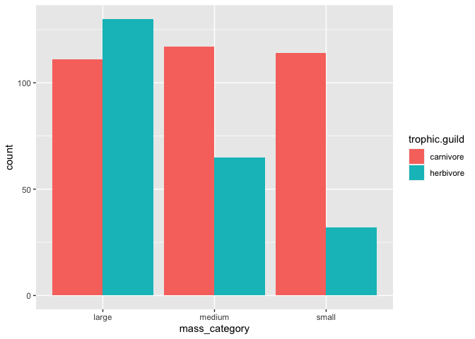

```r
homerange %>%
  mutate(mass_category=case_when(log10.mass<=1.75 ~ "small",
                                 log10.mass>1.75 & log10.mass<=2.75 ~ "medium",
                                 log10.mass>2.75 ~ "large")) %>%
  ggplot(aes(x=mass_category, fill=trophic.guild))+
  geom_bar(position="dodge")
```

## Practice

1. Use case_when() to make a new column `range_category` that breaks down `log10.hra` into very small, small, medium, and large classes based on quartile.

```r
summary(homerange$log10.hra)
```

```
##    Min. 1st Qu.  Median    Mean 3rd Qu.    Max.
##  -1.523   3.653   4.595   4.709   6.016   9.550
```

```r
library(gtools)
#install.packages("gtools")
```

```r
quartiles <- quantcut(homerange$log10.hra)
table(quartiles)
```

```
## quartiles
## [-1.52,3.65]  (3.65,4.59]  (4.59,6.02]  (6.02,9.55]
##          143          142          142          142
```

```r
homerange %>%
  mutate(range_category=case_when(log10.hra<3.65 ~ "very small",
                                  log10.hra>=3.65 & log10.hra<=4.59 ~ "small",
                                  log10.hra>4.59 & log10.hra<=6.02 ~ "medium",
                                  log10.hra>=6.02 ~ "large"))
```

```
## # A tibble: 569 × 25
##    taxon        common.name class order family genus species primarymethod N
##    <chr>        <chr>       <chr> <chr> <chr>  <chr> <chr>   <chr>         <chr>
##  1 lake fishes  american e… acti… angu… angui… angu… rostra… telemetry     16
##  2 river fishes blacktail … acti… cypr… catos… moxo… poecil… mark-recaptu… <NA>
##  3 river fishes central st… acti… cypr… cypri… camp… anomal… mark-recaptu… 20
##  4 river fishes rosyside d… acti… cypr… cypri… clin… fundul… mark-recaptu… 26
##  5 river fishes longnose d… acti… cypr… cypri… rhin… catara… mark-recaptu… 17
##  6 river fishes muskellunge acti… esoc… esoci… esox  masqui… telemetry     5
##  7 marine fish… pollack     acti… gadi… gadid… poll… pollac… telemetry     2
##  8 marine fish… saithe      acti… gadi… gadid… poll… virens  telemetry     2
##  9 marine fish… lined surg… acti… perc… acant… acan… lineat… direct obser… <NA>
## 10 marine fish… orangespin… acti… perc… acant… naso  litura… telemetry     8
## # ℹ 559 more rows
## # ℹ 16 more variables: mean.mass.g <dbl>, log10.mass <dbl>,
## #   alternative.mass.reference <chr>, mean.hra.m2 <dbl>, log10.hra <dbl>,
## #   hra.reference <chr>, realm <chr>, thermoregulation <chr>, locomotion <chr>,
## #   trophic.guild <chr>, dimension <dbl>, preymass <dbl>, log10.preymass <dbl>,
## #   PPMR <dbl>, prey.size.reference <chr>, range_category <chr>
```

2. Make a plot that shows how many and which taxonomic classes are represented in each `range_category`.

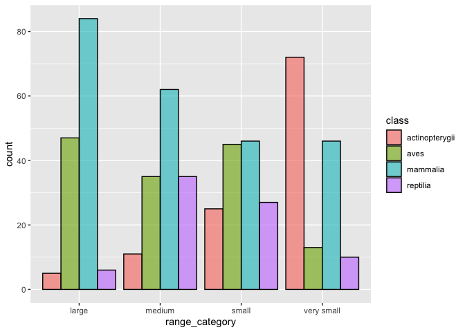

```r
homerange %>%
  mutate(range_category=case_when(log10.hra<3.65 ~ "very small",
                                  log10.hra>=3.65 & log10.hra<=4.59 ~ "small",
                                  log10.hra>4.59 & log10.hra<=6.02 ~ "medium",
                                  log10.hra>=6.02 ~ "large")) %>%
  ggplot(aes(x=range_category, fill=class))+
  geom_bar(position="dodge", alpha=0.6, color="black")
```

3. Isolate the small `range_category` and plot the range of `log10.mass` by taxonomic class.

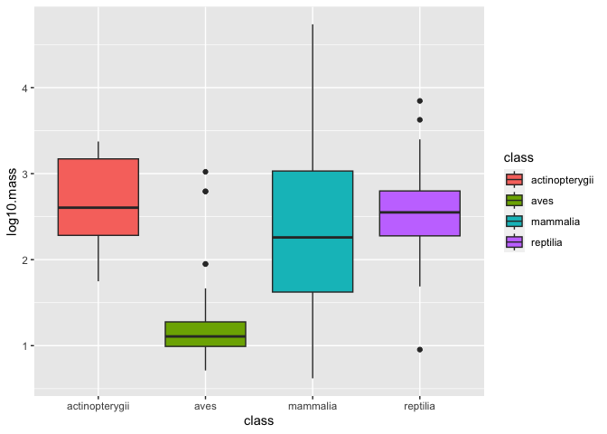

```r
homerange %>%
  mutate(range_category=case_when(log10.hra<3.65 ~ "very small",
                                  log10.hra>=3.65 & log10.hra<=4.59 ~ "small",
                                  log10.hra>4.59 & log10.hra<=6.02 ~ "medium",
                                  log10.hra>=6.02 ~ "large")) %>%
  filter(range_category=="small") %>%
  ggplot(aes(x=class, y=log10.mass, fill=class))+
  geom_boxplot()
```

## Load the libraries

```r
library(tidyverse)
library(RColorBrewer)
library(paletteer)
library(janitor)
```

```r
options(scipen=999) #cancels the use of scientific notation for the session
```

## Data

For this tutorial, we will use:  
[Homerange](http://datadryad.org/resource/doi:10.5061/dryad.q5j65/1). The data are from: Tamburello N, Cote IM, Dulvy NK (2015) Energy and the scaling of animal space use. The American Naturalist 186(2):196-211. http://dx.doi.org/10.1086/682070.

```r
homerange <- read_csv("data/Tamburelloetal_HomeRangeDatabase.csv", na = c("", "NA", "\\"))
```

## ggplot themes

There are many options to change the theme of your plots within ggplot. Have a look [here]https://ggplot2.tidyverse.org/reference/ggtheme.html) for a list of the themes.

Let’s start by building a simple barplot.

```r
p <- homerange %>%
  ggplot(aes(x=taxon, fill=trophic.guild))+
  geom_bar(na.rm=T, position="dodge")
```

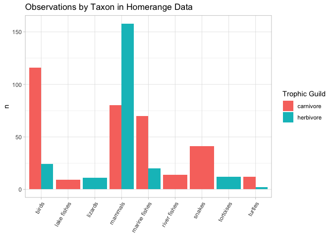

```r
p + theme_light()+
  theme(axis.text.x = element_text(angle = 60, hjust=1))+
  labs(title = "Observations by Taxon in Homerange Data",
       x = NULL,
       y= "n",
       fill= "Trophic Guild")
```

## Practice

1. Build a scatterplot that compares `log10.mass` and `log10.preymass`. Color the points by `taxon`. Store this plot as object `q`.

```r
q <- homerange %>%
  ggplot(aes(x=log10.mass, y=log10.preymass, color=taxon))+
  geom_point(na.rm=T)
```

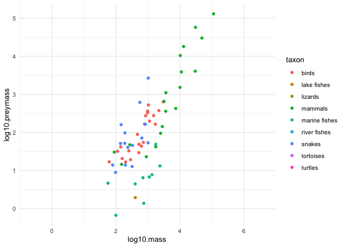

```r
q+theme_minimal()
```

## Legends

There are lots of options to manipulate legends. Have a look [here](http://www.sthda.com/english/wiki/ggplot2-legend-easy-steps-to-change-the-position-and-the-appearance-of-a-graph-legend-in-r-software).

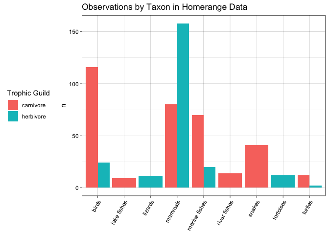

```r
p+theme_linedraw()+
  theme(legend.position = "left",
        axis.text.x = element_text(angle = 60, hjust=1))+
  labs(title = "Observations by Taxon in Homerange Data",
       x = NULL, #removes the label from the x axis
       y= "n",
       fill= "Trophic Guild")
```

## Not enough? Try using `ggthemes`

There are many packages that include additional themes, one of which is [ggthemes](https://yutannihilation.github.io/allYourFigureAreBelongToUs/). Some of these are nice because they are designed to mimic the look of popular publications.

```r
#install.packages("ggthemes")
library(ggthemes)
```

Here is a list of the `ggthemes`

```r
ls("package:ggthemes")[grepl("theme_", ls("package:ggthemes"))]
```

```
##  [1] "theme_base"            "theme_calc"            "theme_clean"
##  [4] "theme_economist"       "theme_economist_white" "theme_excel"
##  [7] "theme_excel_new"       "theme_few"             "theme_fivethirtyeight"
## [10] "theme_foundation"      "theme_gdocs"           "theme_hc"
## [13] "theme_igray"           "theme_map"             "theme_pander"
## [16] "theme_par"             "theme_solarized"       "theme_solarized_2"
## [19] "theme_solid"           "theme_stata"           "theme_tufte"
## [22] "theme_wsj"
```

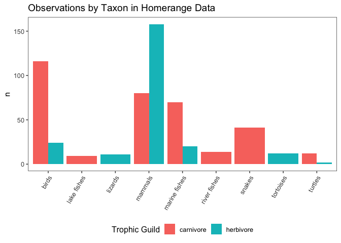

```r
p +
  theme_few()+
  theme(legend.position = "bottom",
        axis.text.x = element_text(angle = 60, hjust=1))+
  labs(title = "Observations by Taxon in Homerange Data",
       x = NULL,
       y= "n",
       fill= "Trophic Guild")
```

## Practice

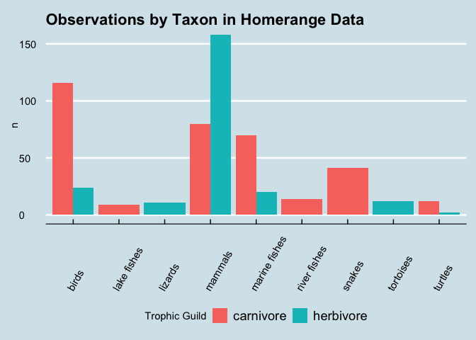

```r
p +
  theme_economist()+
  theme(legend.position = "bottom",
        axis.text.x = element_text(angle = 60, hjust=0))+
  labs(title = "Observations by Taxon in Homerange Data",
       x = NULL,
       y= "n",
       fill= "Trophic Guild")
```

## RColorBrewer

The default colors used by ggplot are often uninspiring. They don’t make plots pop out in presentations or publications, and you may want to use a customized palette to make things visually consistent.

Access the help for `RColorBrewer`.

```r
?RColorBrewer
```

The thing to notice is that there are three different color palettes: 1) sequential, 2) diverging, and 3) qualitative. Within each of these there are several selections. You can bring up the colors by using `display.brewer.pal()`. Specify the number of colors that you want and the palette name.

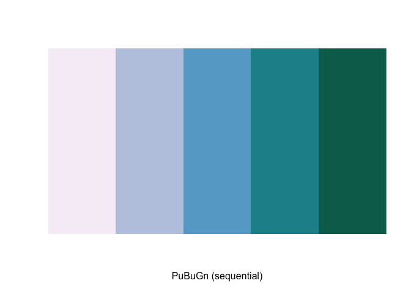

```r
display.brewer.pal(5,"PuBuGn") #sequential palette
```

The [R Color Brewer](http://colorbrewer2.org/#type=sequential&scheme=BuGn&n=3) website is very helpful for getting an idea of the color palettes. To make things easy, use these two guidelines:

+`scale_colour_brewer()` is for points  
+`scale_fill_brewer()` is for fills

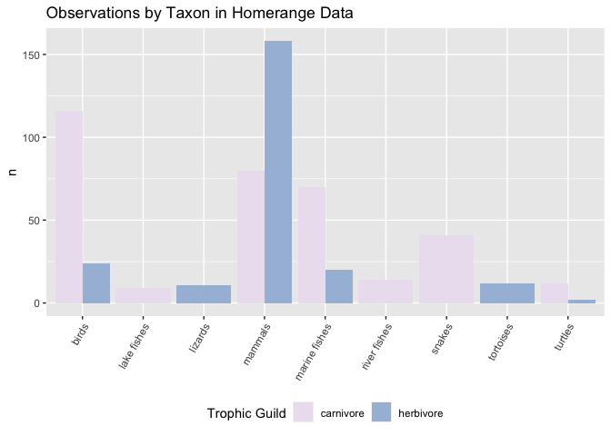

```r
p+scale_fill_brewer(palette = "PuBuGn")+
  theme(legend.position = "bottom",
        axis.text.x = element_text(angle = 60, hjust=1))+
  labs(title = "Observations by Taxon in Homerange Data",
       x = NULL,
       y= "n",
       fill= "Trophic Guild")
```

## Practice

1. Keep using the `same`q` plot, but test out one of R Color Brewer palettes.

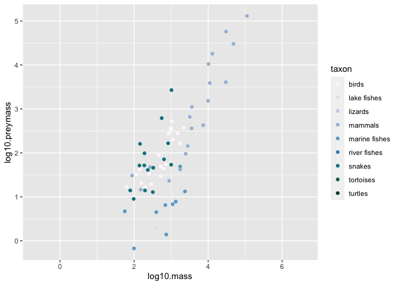

```r
q+scale_colour_brewer(palette = "PuBuGn")
```

## Manually Setting Colors

You can also use `paleteer` to build a custom palette for consistency. To access the `paleteer` collection, I add it to a new object.

```r
colors <- paletteer::palettes_d_names
```

Now we can display the palettes. Assign the palette to `my_palette` and then build this base R bar plot. There are a lot of options; `paleteer` is a collection of popular palettes. I really like the [`ggsci` package] (https://cran.r-project.org/web/packages/ggsci/vignettes/ggsci.html)

```r
my_palette <- paletteer_d("ggsci::nrc_npg") #store your palette
```

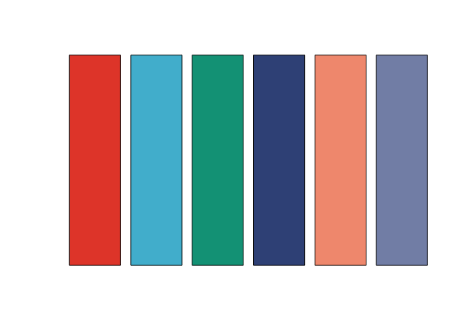

```r
barplot(rep(1,6), axes=FALSE, col=my_palette) # show your palette
```

Now we just identify `my_palette` as part of `scale_fill_manual()`

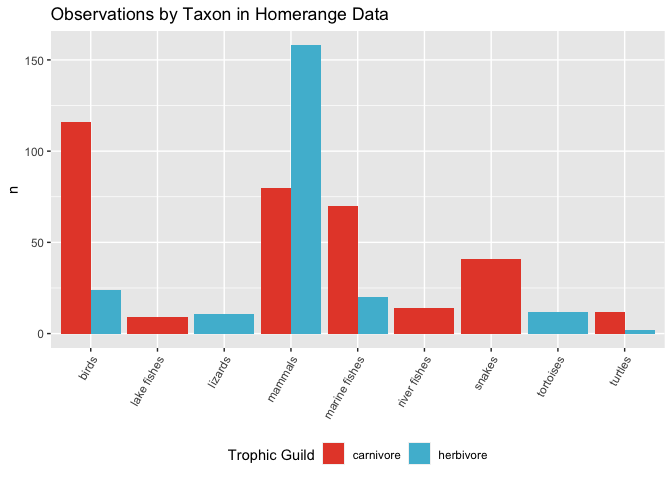

```r
p+scale_fill_manual(values=my_palette)+
  theme(legend.position = "bottom",
        axis.text.x = element_text(angle = 60, hjust=1))+
  labs(title = "Observations by Taxon in Homerange Data",
       x = NULL,
       y= "n",
       fill= "Trophic Guild")
```

## Practice

1. Keep using the `same`q`plot, but test out one of`paleteer` themes.

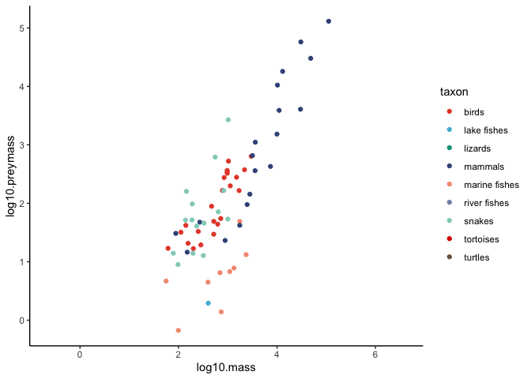

```r
q+theme_classic()+scale_colour_manual(values=my_palette)
```

## Faceting

[Faceting](https://ggplot2-book.org/facet.html) is one of the amazing features of ggplot. It allows us to make multi-panel plots for easy comparison. Here is a boxplot that shows the range of log10.mass by taxon.

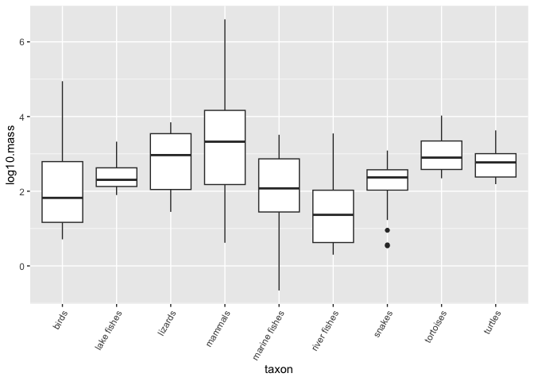

```r
homerange %>%
  ggplot(aes(x=taxon, y=log10.mass))+
  geom_boxplot()+
  theme(axis.text.x = element_text(angle = 60, hjust=1))
```

There are other categorical variables that might be interesting to overlay. `facet_wrap()` makes a ribbon of panels by a specified categorical variable and allows you to control how you want them arranged.

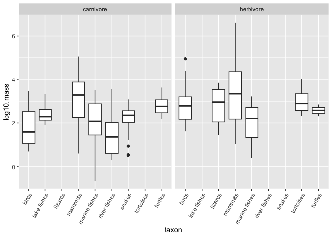

```r
homerange %>%
  ggplot(aes(x=taxon, y=log10.mass))+
  geom_boxplot()+
  facet_wrap(~trophic.guild)+
  theme(axis.text.x = element_text(angle = 60, hjust=1))
```

`facet_grid()` allows control over the faceted variable; it can be arranged in rows or columns. rows~columns.

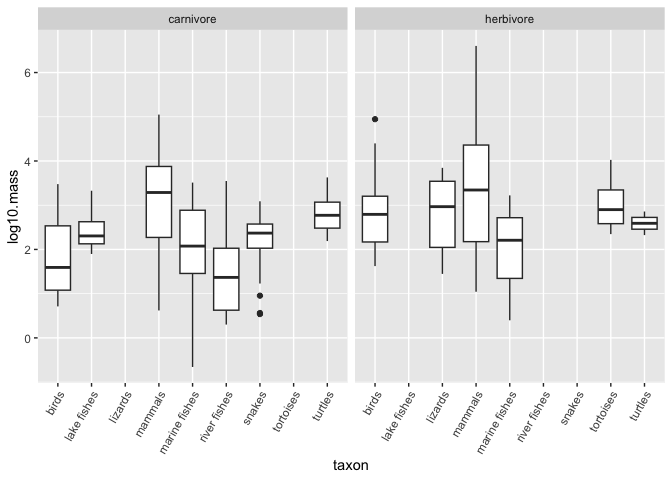

```r
homerange %>%
  ggplot(aes(x=taxon, y=log10.mass))+
  geom_boxplot()+
  facet_grid(.~trophic.guild)+
  theme(axis.text.x = element_text(angle = 60, hjust=1))
```

`facet_grid()` will also allow the comparison of two categorical variables, just remember a~b where a is rows and b is columns.

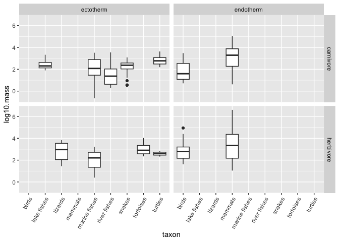

```r
homerange %>%
  ggplot(aes(x=taxon, y=log10.mass))+
  geom_boxplot()+
  facet_grid(trophic.guild~thermoregulation)+
  theme(axis.text.x = element_text(angle = 60, hjust=1))
```